# Heart Attack Prediction

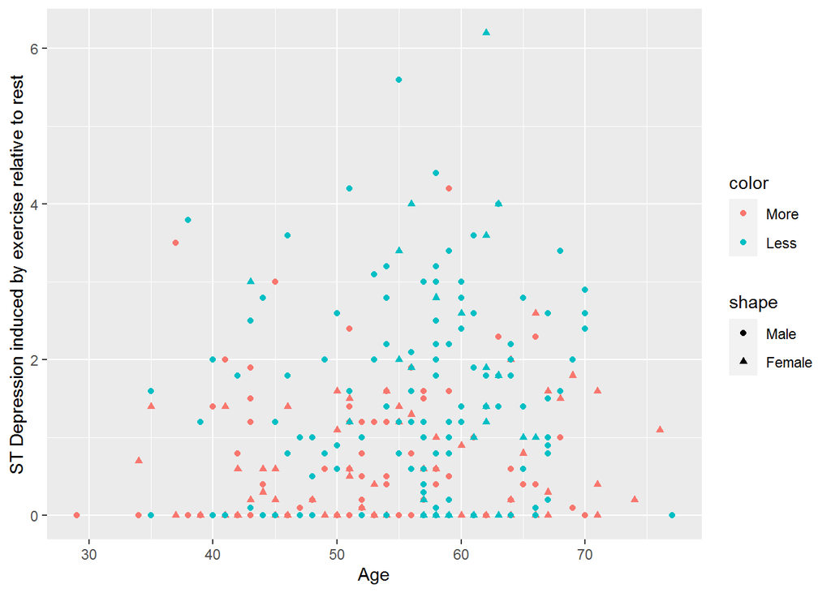

```r
plottingpoint(heart_df$age, "Age", heart_df$oldpeak, "ST Depression induced by exercise relative to rest", heart_df$sex, heart_df$output)
```

Change all factor variable to integer.

```r
heart_df$sex <-as.integer(heart_df$sex)
heart_df$cp <-as.integer(heart_df$cp)
heart_df$fbs <-as.integer(heart_df$fbs)
heart_df$restecg <-as.integer(heart_df$restecg)
heart_df$exng <-as.integer(heart_df$exng)
heart_df$slp <-as.integer(heart_df$slp)
heart_df$caa <-as.integer(heart_df$caa)
heart_df$thall <-as.integer(heart_df$thall)
```

Pearson’s Correlation Coefficient

```r
r <- cor(heart_df[1:13])
r <- round(r,3)
```

Install the required packages.

```r
#install.packages("psych")
library(psych)
```

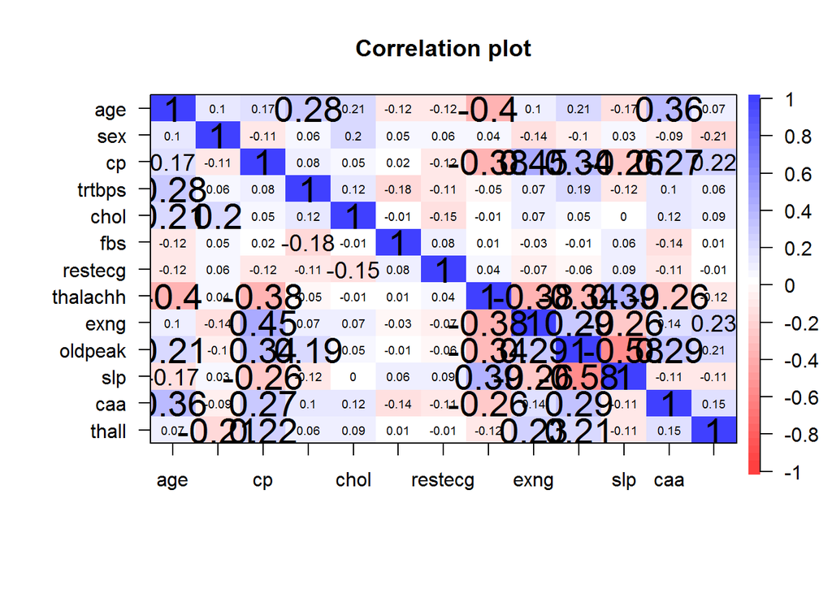

```r
corPlot(heart_df[1:13], cex = 1.2)
```

# 3. Data Preparation

## 3. 1. Data Cleaning

This section is data cleaning.

### 3.1.1. Get Outliers and remove Value in variable trtbps

```r
# Get Outliers and remove Value in variable trtbps
out_trtbps <- boxplot.stats(heart_df$trtbps)$out
out_idx1 <- which(heart_df$trtbps%in%c(out_trtbps))
heart_df_dummy <- heart_df[-out_idx1,]
```

### 3.1.2. Get Outliers and remove Value in variable chol

```r
# Get Outliers and remove Value in variable chol
out_chol <- boxplot.stats(heart_df_dummy$chol)$out
out_idx2 <- which(heart_df_dummy$chol%in%c(out_chol))
heart_df_dummy2 <- heart_df_dummy[-out_idx2,]
```

### 3.1.3. Get Outliers and remove Value in variable thalachh

```r
# Get Outliers and remove Value in variable thalachh
out_thalachh <- boxplot.stats(heart_df_dummy2$thalachh)$out
out_idx3 <- which(heart_df_dummy2$thalachh%in%c(out_thalachh))
heart_df_dummy3 <- heart_df_dummy2[-out_idx3,]
```

### 3.1.4. Get Outliers and remove Value in variable oldpeak

```r
# Get Outliers and remove Value in variable oldpeak
out_oldpeak <- boxplot.stats(heart_df_dummy3$oldpeak)$out
out_idx4 <- which(heart_df_dummy3$oldpeak%in%c(out_oldpeak))
heart_df_new <- heart_df_dummy3[-out_idx4,]
```

### 3.1.5. New Bloxplot without outliers

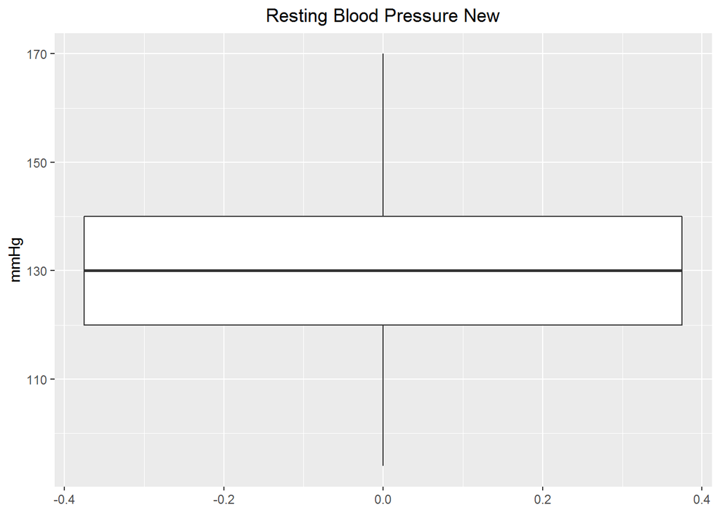

```r
# New Bloxplot without outliers
ggplot(heart_df_dummy, aes(y = trtbps))+
  geom_boxplot()+
  labs (y = "mmHg")+
  ggtitle ("Resting Blood Pressure New")+
  theme(plot.title = element_text(hjust = 0.5))
```

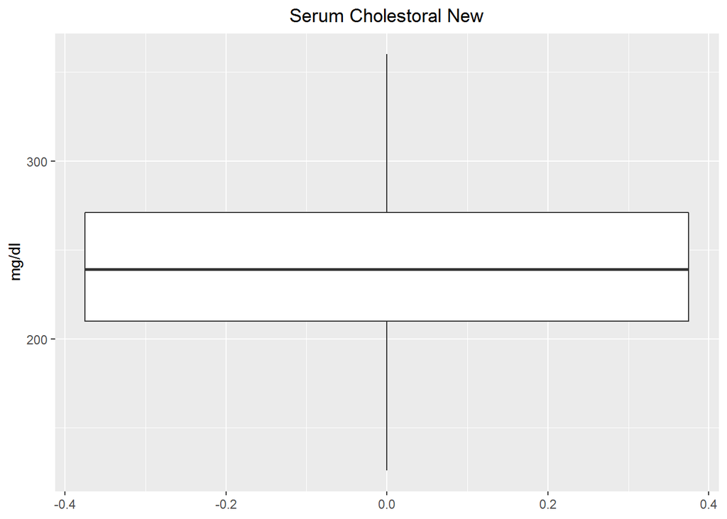

```r
ggplot(heart_df_dummy2, aes(y = chol))+
  geom_boxplot()+
  labs (y = "mg/dl")+
  ggtitle ("Serum Cholestoral New")+
  theme(plot.title = element_text(hjust = 0.5))
```

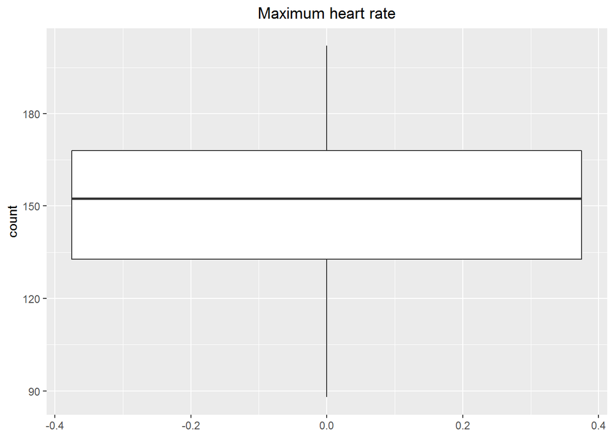

```r
ggplot(heart_df_dummy3, aes(y = thalachh))+
  geom_boxplot()+
  labs (y = "count")+
  ggtitle ("Maximum heart rate")+
  theme(plot.title = element_text(hjust = 0.5))
```

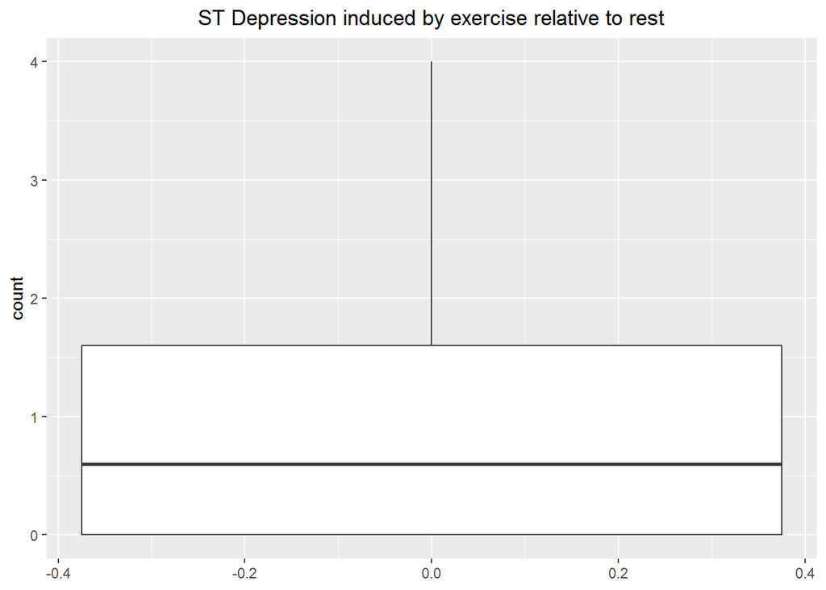

```r
ggplot(heart_df_new, aes(y = oldpeak))+
  geom_boxplot()+
  labs (y = "count")+
  ggtitle ("ST Depression induced by exercise relative to rest")+
  theme(plot.title = element_text(hjust = 0.5))
```

## 3. 2. Remove Rows With Missing Value

```r
heart_df_new <- na.omit(heart_df_new)
```

## 3. 3. New Data Dimension

```r
d <- dim(heart_df_new)
m <- d[1] # m : number of rows
n <- d[2] # n : number of columns
```

## 3. 4. Training and Testing Division

```r
## Train:Test = 70:30
set.seed(2021)

train_idx <- sample(m, 0.7 * m)
train_idx[1:3]
```

```
## [1] 166 231  70
```

```r
train_data <- heart_df_new[ train_idx , ]
test_data <- heart_df_new[ -train_idx , ]
```

# 4. Modeling

# 4.1. Logistic Regression

This part is making logistic regression.

```r
## Logistic Regression
logit <- glm(formula = output ~.  ,
             data = train_data,
             family = binomial)
summary(logit)
```

```
##
## Call:
## glm(formula = output ~ ., family = binomial, data = train_data)
##
## Deviance Residuals:
##      Min        1Q    Median        3Q       Max
## -2.79054  -0.35651  -0.09823   0.34275   2.25960
##
## Coefficients:
##              Estimate Std. Error z value Pr(>|z|)
## (Intercept) -6.402081   4.801449  -1.333  0.18241
## age         -0.030462   0.031843  -0.957  0.33876
## sex         -1.475806   0.628750  -2.347  0.01891 *
## cp           0.462176   0.257813   1.793  0.07302 .
## trtbps       0.042944   0.017507   2.453  0.01417 *
## chol         0.003268   0.006390   0.511  0.60907
## fbs          0.526073   0.794465   0.662  0.50786
## restecg     -0.319345   0.496506  -0.643  0.52010
## thalachh    -0.019513   0.015563  -1.254  0.20992
## exng         1.097746   0.583090   1.883  0.05975 .
## oldpeak      0.391680   0.292114   1.341  0.17997
## slp         -1.444872   0.562342  -2.569  0.01019 *
## caa          1.637935   0.401110   4.084 4.44e-05 ***
## thall        1.490276   0.433111   3.441  0.00058 ***
## ---
## Signif. codes:  0 '***' 0.001 '**' 0.01 '*' 0.05 '.' 0.1 ' ' 1
##
## (Dispersion parameter for binomial family taken to be 1)
##
##     Null deviance: 266.93  on 192  degrees of freedom
## Residual deviance: 110.64  on 179  degrees of freedom
## AIC: 138.64
##
## Number of Fisher Scoring iterations: 6
```

# 4.2. Decision Tree

This part is making a decision tree.

```r
## Decision Tree
library(party)
```

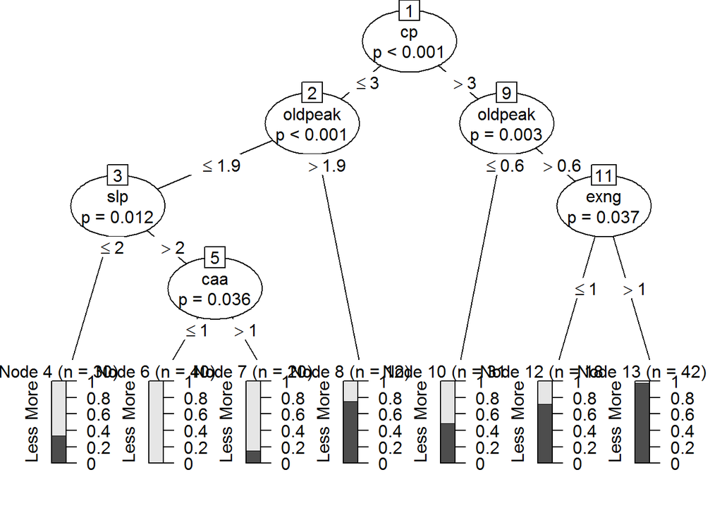

```r
dt <- ctree(formula = output~.,
            data = train_data)
plot(dt)
```

# 4.3. Random Forest

This part is creating a random forest.

```r
## Random Forest
library(randomForest)
set.seed(2021)
rf <- randomForest(formula = output ~.,
                   data =train_data)
rf
```

```
##
## Call:
##  randomForest(formula = output ~ ., data = train_data)
##                Type of random forest: classification
##                      Number of trees: 500
## No. of variables tried at each split: 3
##
##         OOB estimate of  error rate: 14.51%
## Confusion matrix:
##      More Less class.error
## More   90   12   0.1176471
## Less   16   75   0.1758242
```

# 4.4. Support Vector Machine (SVM)

This part is creating a support vector machine.

```r
## Support Vector Machine (SVM)
library(e1071)
model.svm <- svm(formula = output ~.,
                 data = train_data)
model.svm
```

```
##
## Call:
## svm(formula = output ~ ., data = train_data)
##
##
## Parameters:
##    SVM-Type:  C-classification
##  SVM-Kernel:  radial
##        cost:  1
##
## Number of Support Vectors:  111
```

# 5. Evaluation

## Actual Value

This part is creating the actual value.

```r
## Actual Value
actual <- test_data$output
```

# 1. Predicted Output - Logistic Regression

This part is making logistic regression.

```r
# Predicted Output - Logistic Regression
pred.prob <- predict(logit, test_data, type="response")
pred.prob > 0.5
```

```
##     2     3     4     5     6     8    10    11    12    13    16    22    25
##  TRUE FALSE FALSE FALSE FALSE FALSE FALSE FALSE FALSE FALSE FALSE FALSE  TRUE
##    26    30    32    34    36    38    42    44    50    53    55    57    58
## FALSE FALSE FALSE  TRUE  TRUE FALSE FALSE FALSE FALSE  TRUE FALSE FALSE FALSE
##    63    64    65    66    69    77    81    84    85    96    98   103   107
## FALSE FALSE FALSE FALSE FALSE FALSE FALSE  TRUE FALSE  TRUE  TRUE FALSE  TRUE
##   113   115   119   127   130   132   139   142   143   149   153   161   163
## FALSE FALSE FALSE FALSE FALSE FALSE FALSE FALSE FALSE FALSE  TRUE FALSE FALSE
##   167   172   176   178   183   186   188   189   200   201   206   207   210
##  TRUE FALSE  TRUE FALSE FALSE FALSE  TRUE  TRUE FALSE FALSE  TRUE  TRUE  TRUE
##   219   223   225   231   232   241   244   245   254   255   256   263   266
##  TRUE  TRUE  TRUE FALSE  TRUE  TRUE  TRUE  TRUE  TRUE FALSE  TRUE  TRUE FALSE
##   268   271   276   278   298   300
##  TRUE FALSE  TRUE FALSE  TRUE  TRUE
```

```r
pred.logit <- factor(pred.prob > 0.5,
                     levels = c(TRUE,FALSE),
                     labels = c("More","Less"))
```

# 2. Predicted Output - Decision Tree

This part is making decision tree.

```r
# Predicted Output - Decision Tree
pred.dt <- predict(dt, test_data)
```

# 3. Predicted Output - Random Forest

This part is making random forest.

```r
# Prediction Output - Random Forest
pred.rf <- predict(rf, test_data)
```

# 4. Predicted Output - SVM (Support Vector Machine)

This part is making SVM (Support Vector Machine).

```r
# Prediction Output - SVM
pred.svm <- predict(model.svm, test_data)
```

# Confusion Matrix

This part is making Confusion Matrix.

```r
# Confusion Matrix
table.logic <- table(actual, pred.logit,
                     dnn = c("actual","predicted"))
table.logic
```

```
##       predicted
## actual More Less
##   More   10   42
##   Less   21   11
```

```r
table.dt <- table(actual, pred.dt,
                  dnn = c("actual","predicted"))
table.dt
```

```
##       predicted
## actual More Less
##   More   46    6
##   Less   17   15
```

```r
table.rf <- table(actual, pred.rf,
                  dnn = c("actual","predicted"))
table.rf
```

```
##       predicted
## actual More Less
##   More   44    8
##   Less   10   22
```

```r
table.svm <- table(actual, pred.svm,
                   dnn = c("actual","predicted"))
table.svm
```

```
##       predicted
## actual More Less
##   More   41   11
##   Less   10   22
```

## Performance Evaluation

This section is to calculate the evaluation performance, using the classification method.

```r
## Performance Evaluation
performance <- function(prediction, actual, method){

  #1 Create Confusion Matrix (cm)
  cm <- table(actual, prediction,
              dnn = c("actual","predicted"))

  #2. Extract TP, TN, FP, FN
  TP <- cm[1,1]
  TN <- cm[2,2]
  FP <- cm[2,1]
  FN <- cm[1,2]

  #3. Compute accuracy, precision, recall, f1score
  accuracy <- (TP+TN) / (TP+TN+FP+FN)
  precision <- TP/(FP+TP)
  recall <- TP/(FN+TP)
  f1score <- (2*precision*recall)/(precision+recall)

  #4. Prepare output function
  result <-paste("***Method: ", method,
                 "\n Accuracy = ", round(accuracy,3),
                 "\n Precision = ", round(precision,3),
                 "\n Recall = ", round(recall,3),
                 "\n F1 Score = ", round(f1score,3))
  cat (result)
}

performance(pred.logit, actual, "Logistic Regression")
```

```
## ***Method:  Logistic Regression
##  Accuracy =  0.25
##  Precision =  0.323
##  Recall =  0.192
##  F1 Score =  0.241
```

```r
performance(pred.dt, actual, "Decision Tree")
```

```
## ***Method:  Decision Tree
##  Accuracy =  0.726
##  Precision =  0.73
##  Recall =  0.885
##  F1 Score =  0.8
```

```r
performance(pred.rf, actual, "Random Forest")
```

```
## ***Method:  Random Forest
##  Accuracy =  0.786
##  Precision =  0.815
##  Recall =  0.846
##  F1 Score =  0.83
```

```r
performance(pred.svm, actual, "Support Vector Machine")
```

```
## ***Method:  Support Vector Machine
##  Accuracy =  0.75
##  Precision =  0.804
##  Recall =  0.788
##  F1 Score =  0.796
```

# 6. Recommendation